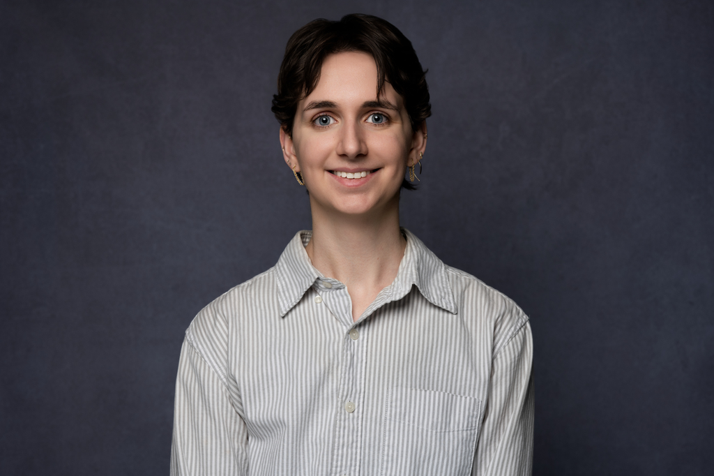

# Hannah Moore

## Bio

Hi! I am a scientist studying long-covid in the Johns Hopkins Department of Molecular and Comparative Pathobiology. My thesis is exploring how immune dysregulation is connected to increased blood brain barrier permeability in people with long-covid. I use data science to analyze high-dimensional data! (Single-cell RNA sequencing, high dimensional flow cytometry, large clinical datasets, etc.)

## Education

**Johns Hopkins School of Medicine** | Baltimore, MD

PhD in Immunology | August 2024-present

**University of Pittsburgh** | Pittsburgh, PA

B.S. in Molecular Biology & Biochemistry | 2018-2022

## Fun Facts:

1. I have a cat (tuxedo) & a gecko (crested)!
2. I love to bake, read, crochet, and take miscellaneous art classes.
3. My favorite books are the Murderbot Diaries and Gideon the Ninth
4. I have POTS and use my lived experience with a post-acute infectious syndrome to inform my research!
5. I have a pothos tattoo that I add to whenever I accomplish something so it grows with me :)

## Resources I Like:

1. [This website is how i’ve learned to create R packages](https://r-pkgs.org/whole-game.html)
2. [This website is great for thinking about color blindness when making color palettes](https://sronpersonalpages.nl/~pault/)
3. [My first stop when I am not sure how to make a graph](https://r-graph-gallery.com/)